# FordGoBike 2018FY

##### by Milind Singh

1. Introduction
2. Gathering Data
3. Assessing Data
4. Cleaning Data
5. Univariate Exploration
6. Bivariate Exploration
7. Multivariate Exploration
8. Conclusions

# Introduction

> Ford GoBike is the Bay Area's bike share system. Bay Area Bike Share was introduced in 2013 as a pilot program for the region, with 700 bikes and 70 stations across San Francisco and San Jose. Once expansion is complete, Ford GoBike will grow to 7,000 bikes across San Francisco, the East Bay and San Jose.

> The bikes are available for use 24 hours/day, 7 days/week, 365 days/year and riders have access to all bikes in the network when they become a member or purchase a pass.

##### Dataset Structure

Originally there were approx. 186,3721 bike rides that happen in 2018 the San Francisco Bay area of California, USA documented. This notebook uses data collected from January 2018 through December 2018. The column header descriptions are as follows:

- trip duration: start/end time, how long the trip took in seconds
- stations: start/end station, name, geolocation (latitude/longitude)
- anonymized customer data: user type
- rented bikes: bike id

**Following Columns are added during cleaning process**

- Start Time Month
- Start Time Month Number
- Start Time Day of the Week
- Start Time Hour
- Distance (km)
- Distance (miles)

**What are the main features of interest in your dataset?**

- The main features include data related to the start and end of a ride. This can be used to calculate when bikes are in high or low demand.
- These features can be used to make business decisions such as which age group to target in marketing campaigns, or which day of the week bikes should be most available.

**What features in the dataset will help support your investigation into your features of interest?**

- The start and end times, and related time-based information will be utilized heavily. I will use the customer related data, as well as the distance to understand the user-driven data behind each ride.

## A) Univariate Exploration

> In this section, I investigate distributions of individual variables.

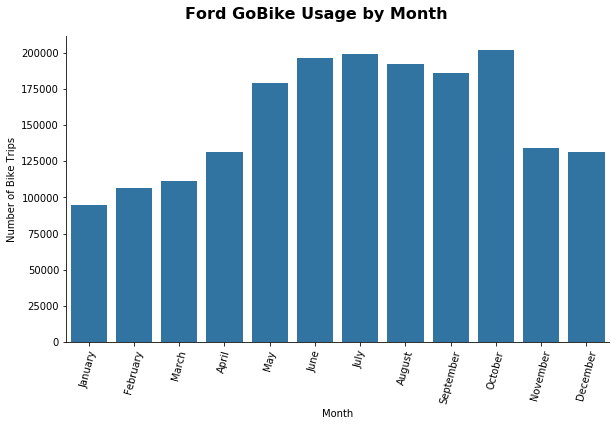

```python
# Monthly usage of the Ford Go Bike system

no_color = sns.color_palette()[0]
graph = sns.catplot(data = df_clean, x = 'start_time_month', kind = 'count', color = no_color, aspect = 1.7);
graph.set_axis_labels('Month', 'Number of Bike Trips'),
graph.fig.suptitle('Ford GoBike Usage by Month', y = 1.05, fontsize = 16, fontweight = 'bold');
graph.set_xticklabels(rotation=75);
```

> **Observation:** The most popular times to use the Ford Go Bike sharing system is Summer season from June to October. October is most popular month followed by july. And in Winter season the use of Ford Go Bike sharing system is decreased.

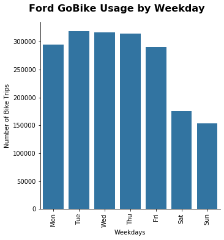

```python
# Weekly usage of the Ford Go bike system

weekday = ['Mon', 'Tue', 'Wed', 'Thu', 'Fri', 'Sat', 'Sun']
graph = sns.catplot(data=df_clean, x='start_time_weekday', kind='count', color = no_color, order = weekday)
graph.set_axis_labels('Weekdays', 'Number of Bike Trips')
graph.fig.suptitle('Ford GoBike Usage by Weekday', y=1.05, fontsize=16, fontweight='bold');
graph.set_xticklabels(rotation=90);
```

> **Observation:** Tuesdays followed by Wednesdays and Thursday seem to be the most popular days for using the bike sharing system. Sunday is least popular days in the week, we can conclude that, Ford bike share system is used primarily for commuting purposes during working days.

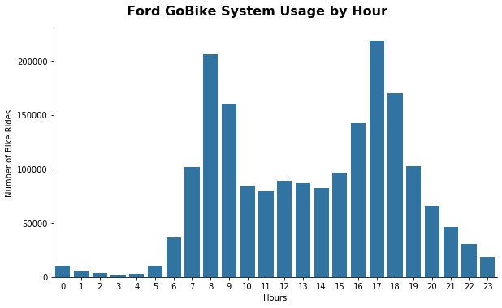

```python
# Hourly usage of the Ford Go Bike System

graph = sns.catplot(data = df_cleaned, x='start_time_hour', kind='count', color = no_color, aspect = 1.7)
graph.set_axis_labels('Hours', 'Number of Bike Rides')
graph.fig.suptitle('Ford GoBike System Usage by Hour', y=1.05, fontsize=16, fontweight='bold');
```

> **Observation:** This Observation also shows that the use of Ford go bike is used only in working hours.The distribution is bimodal,here we can se that he pick time for using Ford Go Bike is between 8-9 AM and 5-6 PM.

## B) Bivariate Exploration

```python
# calculating % split for the user type
customer = df_clean.query('user_type == "Customer"')['bike_id'].count()
subscriber = df_clean.query('user_type == "Subscriber"')['bike_id'].count()

customer_proportion = customer / df_clean['bike_id'].count()
subscriber_proportion = subscriber / df_clean['bike_id'].count()
```

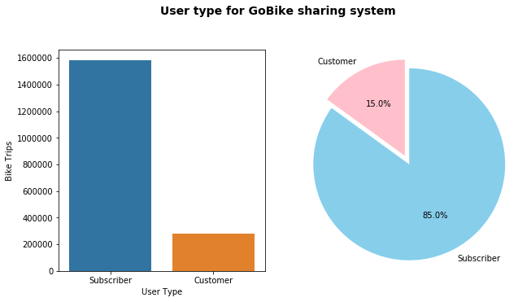

```python
plt.figure(figsize = [10, 5])

# code for the bar chart
plt.subplot(1, 2, 1)

g = sns.countplot(data=df_clean, x="user_type", order=df_clean.user_type.value_counts().index)
g.set_xlabel('User Type')
g.set_ylabel('Bike Trips')

# code for the pie chart
plt.subplot(1, 2, 2)

labels = ['Customer', 'Subscriber']
sizes = [customer_proportion, subscriber_proportion]
colors = ['pink', 'skyblue']
explode = (0, 0.1)

plt.pie(sizes, explode=explode, labels=labels, colors = colors,
        autopct='%1.1f%%', shadow=False, startangle=90)
plt.axis('equal')

plt.suptitle('User type for GoBike sharing system', y=1.03, fontsize=14, fontweight='bold');
```

> **Observation:** The bike sharing system is mainly used by subscribers (85%) than ocassional riders (15%).

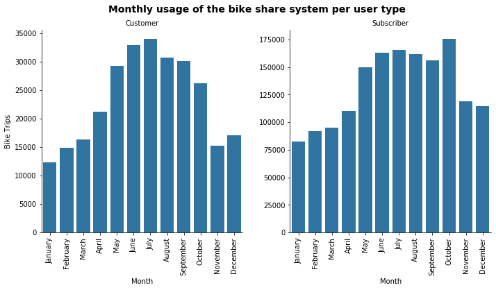

```python
# monthly usege of the bike sharing system by user type
g = sns.catplot(data=df_clean, x='start_time_month', col="user_type", kind='count', sharey = False,
            color = no_color)
g.set_axis_labels("Month", "Bike Trips")
g.set_titles("{col_name}")
g.fig.suptitle('Monthly usage of the bike share system per user type', y=1.03, fontsize=14, fontweight='semibold');
g.set_xticklabels(rotation=90);
```

**Observation:**

> Winter months are the worst for the bike sharing system for both groups what can be determined by the harsher weather.

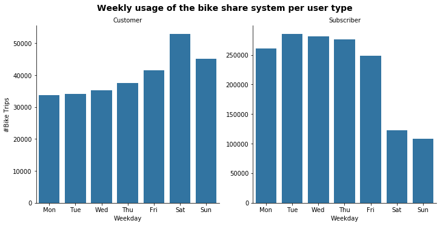

```python
# weekday usege of the bike sharing system per user type
weekday = ['Mon', 'Tue', 'Wed', 'Thu', 'Fri', 'Sat', 'Sun']
g = sns.catplot(data=df_clean, x='start_time_weekday', col="user_type", kind='count', sharey = False,
            color = no_color, order = weekday)
g.set_axis_labels("Weekday", "#Bike Trips")
g.set_titles("{col_name}")
g.fig.suptitle('Weekly usage of the bike share system per user type', y=1.03, fontsize=14, fontweight='semibold');
```

**Observation:** >There is totally a different trend in Customer and Subscriber in weekdays.As mentioned above customers are most probably occasional riders and tourist who use the bike sharing system on holiday or weekend trips. On the other hand, subscribers are most probably daily work/school commuters who use the system within a week.

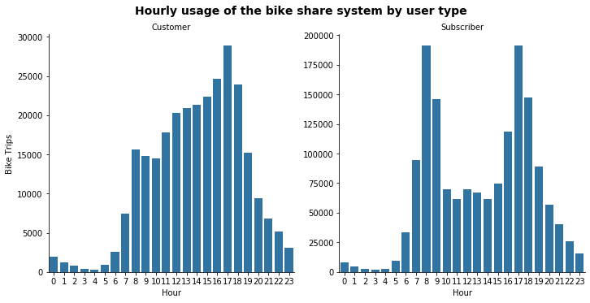

```python
# hourly usege of the bike sharing system per user type
g = sns.catplot(data=df_clean, x='start_time_hour', col="user_type", kind='count', sharey = False,color = no_color)
g.set_axis_labels("Hour", "Bike Trips")
g.set_titles("{col_name}")
g.fig.suptitle('Hourly usage of the bike share system by user type', y=1.03, fontsize=14, fontweight='semibold');
```

**Observation:** There is a different trend between customers and subscribers, here we can see that the **Customers** use bikes from 7AM to 8PM but mainly active between 4-6PM. but the **Subscribers** mainly use bike between 7-9AM and then between 4-6PM.

## C) Multivariate Exploration

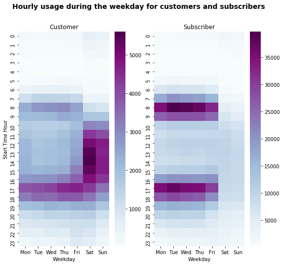

```python
# Weekday order
df_clean['start_time_weekday'] = pd.Categorical(df_clean['start_time_weekday'],
                                                categories=['Mon','Tue','Wed','Thu','Fri','Sat', 'Sun'],
                                                ordered=True)
plt.figure(figsize=(9,8))
plt.suptitle('Hourly usage during the weekday for customers and subscribers', fontsize=14, fontweight='semibold')

# heatmap for customers
plt.subplot(1, 2, 1)
df_customer = df_clean.query('user_type == "Customer"').groupby(["start_time_hour", "start_time_weekday"])["bike_id"].size().reset_index()
df_customer = df_customer.pivot("start_time_hour", "start_time_weekday", "bike_id")
sns.heatmap(df_customer, cmap="BuPu")

plt.title("Customer", y=1.015)
plt.xlabel('Weekday')
plt.ylabel('Start Time Hour')

# heatmap for subscribers
plt.subplot(1, 2, 2)
df_subscriber = df_clean.query('user_type == "Subscriber"').groupby(["start_time_hour", "start_time_weekday"])["bike_id"].size().reset_index()
df_subscriber = df_subscriber.pivot("start_time_hour", "start_time_weekday", "bike_id")
sns.heatmap(df_subscriber, cmap="BuPu")

plt.title("Subscriber", y=1.015)
plt.xlabel('Weekday')
plt.ylabel('');
```

**Observation**

**Customers use the bike sharing system more often on weekends:**

- weekdays: most bike rides hapen around 8-9am and 5-6pm with the peak on Fridays around 5pm
- weekends: most bike rides happen between 10am - 8pm with the peak on Saturdays around 2pm

**Subscribers use the bike sharing system mainly on weekdays:**

- weekdays: most bike rides hapen around 8-9am and 5-6pm with the peak on Tuesdays around 8am
- weekends: bikes are still rented but there is a significant drop in numbers of rented bikes throughout the entire weekends

# Conclusion

There are two types of clients using the system: Subscribers and Customers. Subscribers are primarily daily commuters, having short trips to and from work, who rent a bike on weekdays at 8-9am and 5-6pm, and, occasionally around lunch time. Customers are usually tourists or occassional riders who use the system mainly on weekends to explore the Bay Area.

Renting a bike from theFord GoBike System is a fantastic (healthy and environmentally friendly) way of moving around in the city, both for enjoyment and work.

**Benefits:**

- Environmentally friendly, budget friendly, and lifetsyle friendly.
- Subscribers (i.e. daily commuters) benefit from a health commuting choice
- Customers (i.e. tourists, students, etc.) have a sustainable, yet flexible option for touring the city.
- Affordable and convenient transportation for the people of all socioeconomic classes